# Trabalho de Análise Multivariada

Temos 6 grupos de interesse (Presídios):

1 - Bangu  
2 - Central  
3 - Mossoro  
4 - Papuda  
5 - Pedrinhas  
6 - Pereirão

Para cada presídio, temos observações das seguintes variáveis:

Escala fatorial de socialização - EFS  
Hipótese psíquico social - HPC  
Escala de ansiedade de beck - BAI  
Escala de depressão de beck - BDI  
A Escala de Maturidade Mental Colúmbia - Columbia  
Escala Beck Ideação Suicida - BSI  
Escala de Autenticidade, Agressividade e Inibição – EdAAI

# 1) Análise descritiva dos dados;

| Presidio | Med_Columbia | Var_Columbia | Med_EFS | Var_EFS | Med_HPC | Var_HPC | Med_BAI | Var_BAI | Med_BDI | Var_BDI | Med_BSI | Var_BSI | Med_EdAAI | Var_EdAAI |
| --- | --- | --- | --- | --- | --- | --- | --- | --- | --- | --- | --- | --- | --- | --- |
| Bangu | 21.750 | 11.731 | 21.700 | 12.523 | 40.400 | 11.528 | 33.825 | 5.584 | 45.975 | 8.076 | 34.250 | 7.833 | 22.125 | 11.753 |
| Central | 10.263 | 9.760 | 8.842 | 10.474 | 17.211 | 8.953 | 15.368 | 7.912 | 19.368 | 6.801 | 14.000 | 6.444 | 9.053 | 17.608 |
| Mossoro | 9.680 | 3.936 | 9.920 | 7.300 | 17.700 | 4.867 | 14.640 | 2.031 | 19.520 | 3.928 | 14.680 | 2.630 | 9.720 | 5.798 |
| Papuda | 9.356 | 3.788 | 9.370 | 9.931 | 17.521 | 5.614 | 14.534 | 2.225 | 19.151 | 3.574 | 14.658 | 3.867 | 9.534 | 7.225 |
| Pedrinhas | 9.354 | 9.170 | 9.396 | 13.904 | 17.500 | 12.766 | 14.312 | 5.836 | 19.542 | 5.275 | 14.271 | 5.478 | 8.938 | 16.358 |
| Pereirao | 21.833 | 5.454 | 22.500 | 3.776 | 40.500 | 4.810 | 33.700 | 2.148 | 45.367 | 2.654 | 34.267 | 3.857 | 22.767 | 4.944 |

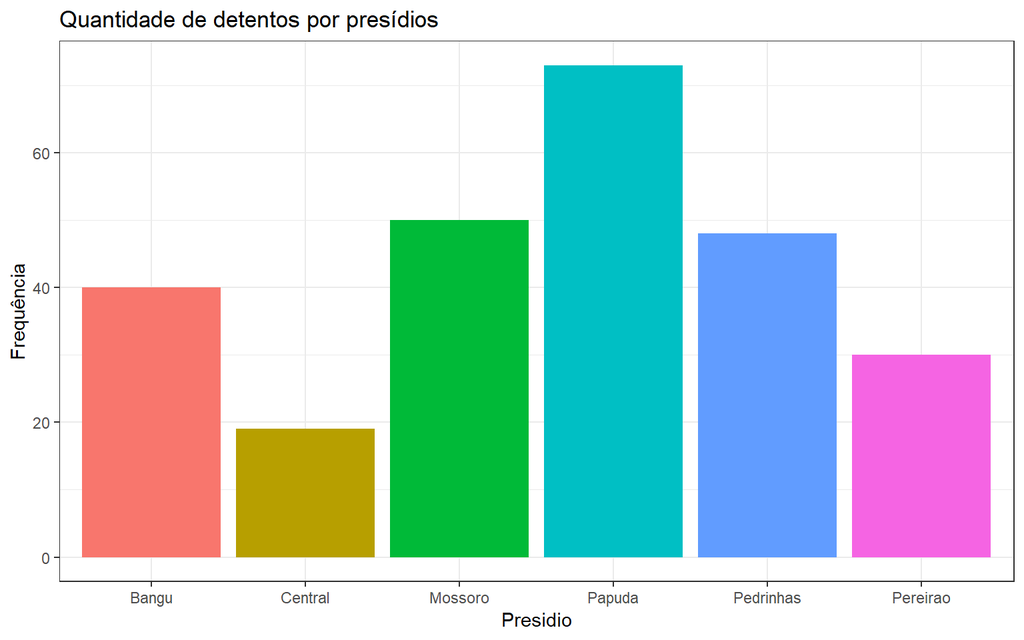

Observa-se que o presídio de Papuda concentra a maior quantidade de detentos, enquanto o presídio da Central possui a menor quantidade. Os de mais possuem números parecidos.

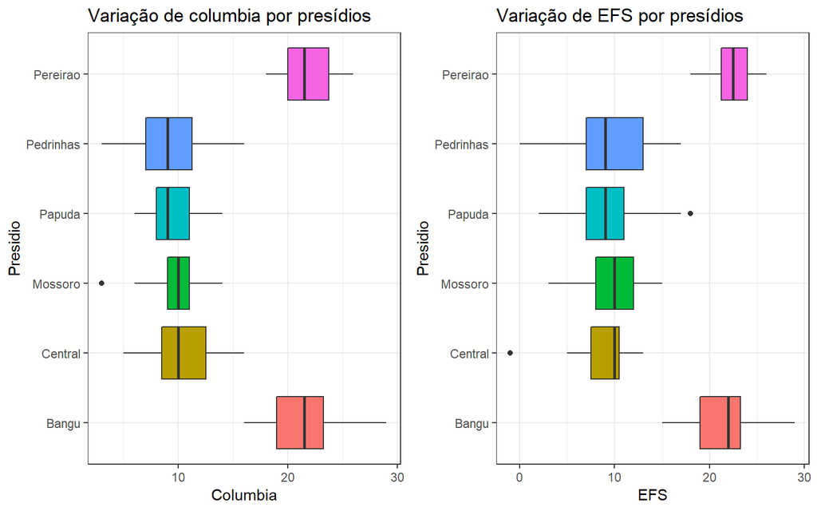

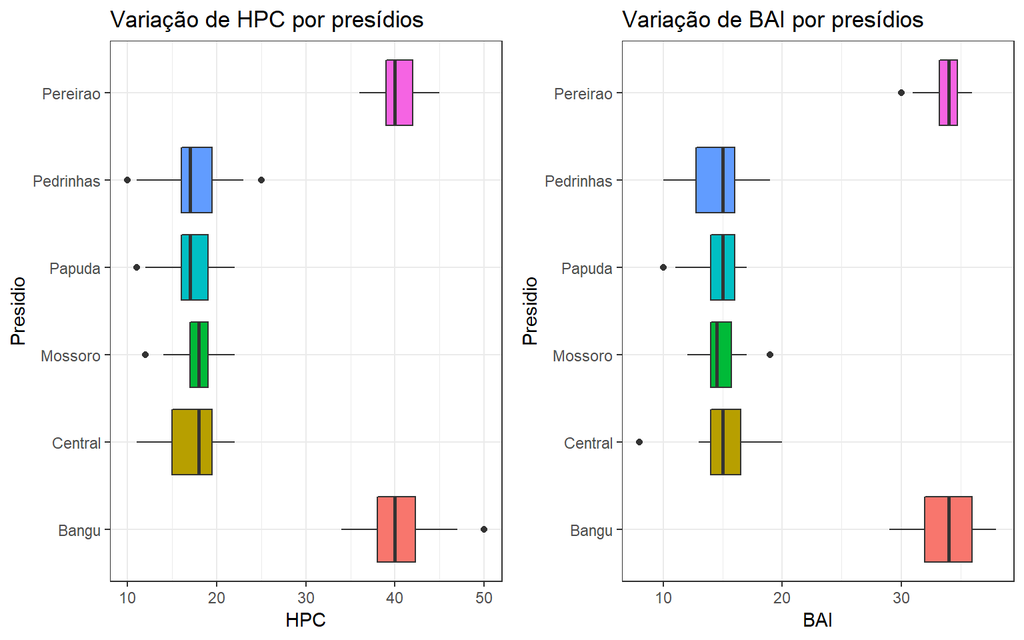

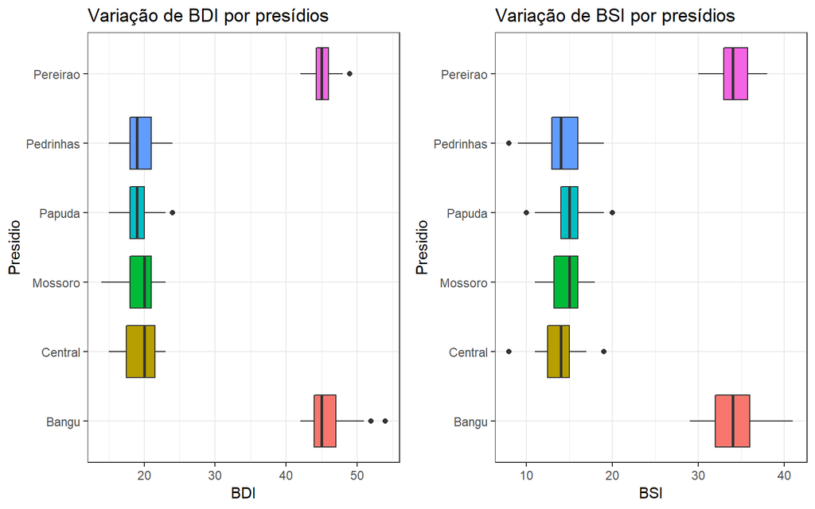

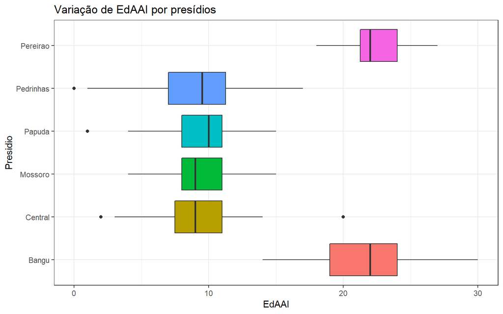

Podemos separar os presídios em dois grupos. O primeiro grupo que possui Pereirão e Bangu e o segundo grupo que possui os de mais. O comportamento das variáveis são diferentes comparando os grupos, porém dentro de cada grupo os comportamentos são parecidos.

Nos boxplots, em especial, é observado que o primeiro grupo possui observações das variáveis Columbia, EFS, HPC, BAI, BDI, BSI e EdAAI altas enquanto o segundo possui observações baixas.

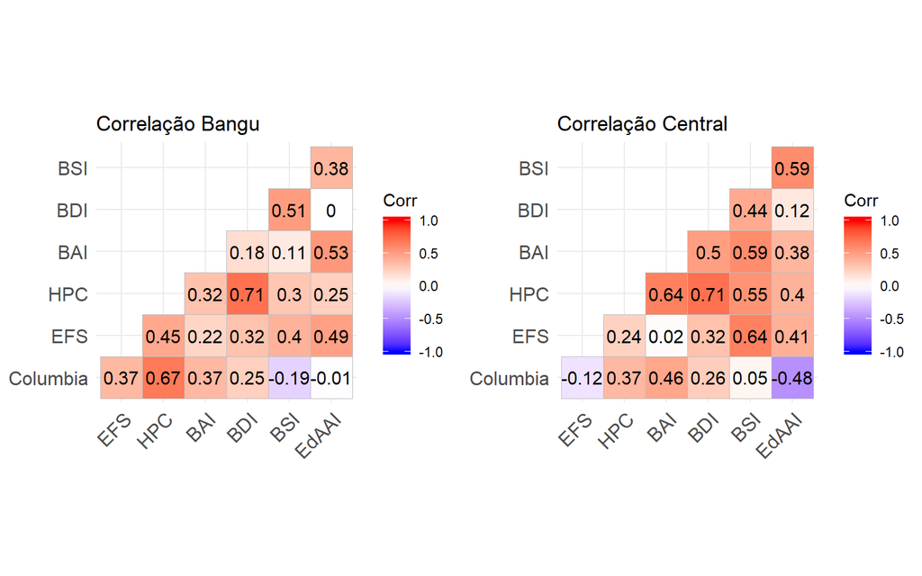

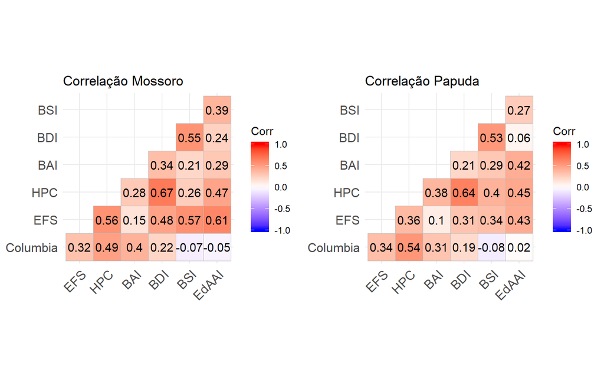

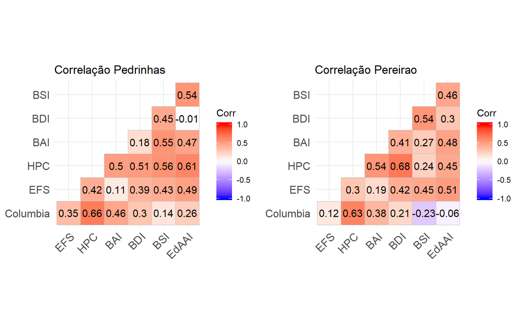

# 2) Teste de Normalidade e Independência;

Hipóteses do teste de Normalidade

$H_0:$ Segue distribuição normal $\times$ $H_1:$ Não segue distribuição normal

```r
presidios = BD %>%
  select(Presidio) %>%
  distinct() %>%
  pull() %>%
  as.character()

p_valor = c()
for(i in presidios){
  p_valor = c(p_valor,mvShapiroTest::mvShapiro.Test(as.matrix(select(filter(BD,Presidio == i),-1)))$p.value)
}
normalidade = tibble(presidios,
                     p_valor) %>%
  mutate(normal = if_else(p_valor > 0.05,"Sim","Não"))
```

Trabalhando a um nível de significância $\alpha$ = 5%, temos para os testes de normalidade das populações:

| presidios | p_valor | normal |
| --- | --- | --- |
| Bangu | 0.4577626 | Sim |
| Central | 0.6611111 | Sim |
| Mossoro | 0.7159016 | Sim |
| Papuda | 0.0583212 | Sim |
| Pedrinhas | 0.7425311 | Sim |
| Pereirao | 0.0074474 | Não |

Pelo teste realizado, observamos que pereirão não possui normalidade confirmada. Porém para realizar futuros testes, iremos supor sua normalidade.

Teste de normalidade geral:

```r
mvShapiroTest::mvShapiro.Test(as.matrix(BD[,-1]))$p.value
```

```
[1] 0.01352637
```

Ao nível de significância de $\alpha$ = 5%, recusamos normalidade dos dados de maneira geral. Porém para realização dos testes futuros iremos supor que a hipótese de normalidade geral dos dados é satisfeita.

Para o teste de indepedência das variáveis:

$H_0:$ $\sigma_{ij}$ = $0$, $\forall$ i $\neq$ j $\times$ $H_1:$ pelo menos um $\sigma_{ij} \neq 0$

Vamos usar a seguinte estatística de teste:
$$-\displaystyle\left[\left(n-1\right) \frac{\left(2p+5\right)}{6}\right]\ln{\mid R \mid} \sim \chi^2_{\frac{p(p-1)}{2}}$$

```r
ind = function(data){
  R = cor(data); p <- ncol(data)
  n = nrow(data)
  est = -((n-1)-(2*p+5)/6)*log(det(R))
  return(est)
}
T2 = ind(BD[,-1])
RC = qchisq(0.05, 6*7/2)
```

Estatística:

```r
T2
```

```
[1] 4174.752
```

Região de Confiança à um nível de significância $\alpha$ = 5% :

```r
RC
```

```
[1] 11.59131
```

P-valor:

```r
pchisq(T2, 6*7/2, lower.tail = F)
```

```
[1] 0
```

Temos que T2 > RC, logo ao nível de significância de 5% rejeitamos a hipótese nula, ou seja, as variáveis são dependentes.

# 3) Teste de média entre os grupos definidos pela variável “Presidio”, 2 a 2;

Primeiro iremos realizar um teste de igualdade de variâncias dois a dois utilizando o pacote MVTests

$H_0:$ $\Sigma_1=\Sigma_2$ $\times$ $H_1:$ $\Sigma_1\neq\Sigma_2$

```r
testa_var = function(base){
  p_valor = c()
  primeiro = c()
  segundo = c()
  combinacoes = combn(as.vector(unique(base[,1])),2)
  variancias = c()
  for(i in 1:length(combinacoes[1,])){
    x1 = combinacoes[,i][1]
    x2 = combinacoes[,i][2]
    bd_aux = BD %>% filter(Presidio==x1 | Presidio ==x2)#
    bd_aux = arrange(bd_aux, Presidio)#
    teste = MVTests::BoxM(as.vector(bd_aux[,-1]),as.vector(bd_aux[,1]))
    p_valor = c(p_valor, teste$p.value)
    primeiro = c(primeiro, x1)
    segundo = c(segundo, x2)
    if(teste$p.value > 0.05) variancias = c(variancias, "Iguais")
    else variancias = c(variancias, "Diferentes")
  }
  resultado = tibble(Presidio1 = primeiro,
                    Presidio2 = segundo,
                    p_valor = p_valor,
                    "Variâncias" = variancias)
  return(resultado)
}

teste_var_2x2 = testa_var(BD) %>%
  mutate_if(is.numeric, function(x) ifelse(x<0.001,"<0.001", round(x,3)))
```

Trabalhando a um nível de significância $\alpha$ = 5%, obteve-se:

| Presidio1 | Presidio2 | p_valor | Variâncias |
| --- | --- | --- | --- |
| Bangu | Central | 0.326 | Iguais |
| Bangu | Mossoro | <0.001 | Diferentes |
| Bangu | Papuda | 0.013 | Diferentes |
| Bangu | Pedrinhas | 0.368 | Iguais |
| Bangu | Pereirao | 0.023 | Diferentes |
| Central | Mossoro | 0.01 | Diferentes |
| Central | Papuda | 0.023 | Diferentes |
| Central | Pedrinhas | 0.439 | Iguais |
| Central | Pereirao | 0.038 | Diferentes |
| Mossoro | Papuda | 0.358 | Iguais |
| Mossoro | Pedrinhas | <0.001 | Diferentes |
| Mossoro | Pereirao | 0.86 | Iguais |
| Papuda | Pedrinhas | 0.007 | Diferentes |
| Papuda | Pereirao | 0.745 | Iguais |
| Pedrinhas | Pereirao | 0.003 | Diferentes |

Agora iremos realizar uma comparação do teste de média de 2 populações com variâncias iguais fornecido pelo pacote com a estatística de teste vista em sala de aula. Iremos utilizar os presídios de Bangu e Central.

$H_0:$ $\mu_1-\mu_2=\delta_0$ $\times$ $H_1:$ $\mu_1-\mu_2\neq\delta_0$

Estatística de Teste:

$S_{p} = \displaystyle\frac{n_{1} - 1}{n - 2}S_{1} + \displaystyle\frac{n_{2} - 1}{n - 2}S_{2}$, onde $n = n_{1} + n_{2}$

$S_{past} = \displaystyle\left(\frac{1}{n_{1}} + \frac{1}{n_{2}}\right)S_{p}$

$T^2 = \left(\bar{x}_{1} - \bar{x}_{2} -\delta\right)^{'}S_{past}^{-1}\left(\bar{x}_{1} - \bar{x}_{2} -\delta\right)$

Saída do pacote:

```r
BD_ban_cen = BD %>%
  filter(Presidio %in% c("Bangu","Central")) %>%
  arrange(Presidio)
qtd_ban_cen = BD_ban_cen %>%
  group_by(Presidio) %>%
  summarize(n())

MVTests::TwoSamplesHT2(BD_ban_cen[,-1],
                       c(rep(1,qtd_ban_cen[1,2]),rep(2,qtd_ban_cen[2,2])))
```

```
$HT2
         [,1]
[1,] 1662.785

$F
         [,1]
[1,] 212.5364

$df
[1]  7 51

$p.value
             [,1]
[1,] 2.002383e-35

$CI
             Lower    Upper Important Variables?
Columbia  7.638278 15.33541               *TRUE*
EFS       8.878615 16.83717               *TRUE*
HPC      19.409678 26.96927               *TRUE*
BAI      15.553872 21.35929               *TRUE*
BDI      23.407896 29.80526               *TRUE*
BSI      17.109979 23.39002               *TRUE*
EdAAI     8.813690 17.33105               *TRUE*

$alpha
[1] 0.05

$Descriptive1
       Columbia       EFS       HPC       BAI      BDI       BSI     EdAAI
Means 21.750000 21.700000 40.400000 33.825000 45.97500 34.250000 22.125000
Sd     3.425021  3.538796  3.395321  2.363043  2.84188  2.798809  3.428295

$Descriptive2
       Columbia      EFS       HPC       BAI       BDI       BSI    EdAAI
Means 10.263158 8.842105 17.210526 15.368421 19.368421 14.000000 9.052632
Sd     3.124137 3.236307  2.992193  2.812878  2.607905  2.538591 4.196211

$Test
[1] "TwoSamplesHT2"

attr(,"class")
[1] "MVTests" "list"
```

Calculo da estatística de teste vista em sala de aula:

```r
difmedia_VarIgual <- function(data, X1, X2, delta = 0){
  X1 = filter(data, data$Presidio == X1)[, -1]
  X2 = filter(data, data$Presidio == X2)[, -1]
  n1 = nrow(X1)
  n2 = nrow(X2)
  n = n1 + n2
  p = ncol(X1)
  X1media = colMeans(X1)
  S1 = var(X1)
  X2media = colMeans(X2)
  S2 = var(X2)
  Sp = ((n1-1)*S1 + (n2-1)*S2)/(n -2)
  Xd = X1media - X2media
  Spast = (1/n1 + 1/n2)*Sp
  T2 = t(Xd - delta)%*%solve(Spast)%*%(Xd - delta)
  saida = list(T2 = T2)
  return(saida)
}

difmedia_VarIgual(BD,"Bangu","Central")
```

```
$T2
         [,1]
[1,] 1662.785
```

As estatísticas de teste são as mesmas.

Agora iremos realizar uma comparação do teste de média de 2 populações com variâncias diferentes fornecido pelo pacote com a estatística de teste vista em sala de aula. Iremos utilizar os presídios de Bangu e Mossoro.

$H_0:$ $\mu_1-\mu_2=\delta_0$ $\times$ $H_1:$ $\mu_1-\mu_2\neq\delta_0$

Estatística de Teste:

$S_{past} = \displaystyle\frac{S_{1}}{n_{1}} + \frac{S_{2}}{n_{2}}$

$T^2 = \left(\bar{x}_{1} - \bar{x}_{2} -\delta\right)^{'}S_{past}^{-1}\left(\bar{x}_{1} - \bar{x}_{2} -\delta\right)$

Saída do pacote:

```r
BD_ban_mos = BD %>%
  filter(Presidio %in% c("Bangu","Mossoro")) %>%
  arrange(Presidio)
qtd_ban_mos = BD_ban_mos %>%
  group_by(Presidio) %>%
  summarize(n())


MVTests::TwoSamplesHT2(BD_ban_mos[,-1],
                       c(rep(1,qtd_ban_mos[1,2]),rep(2,qtd_ban_mos[2,2])),
                       Homogenity = FALSE)
```

```
$HT2
         [,1]
[1,] 4155.356

$F
         [,1]
[1,] 538.8664

$df
[1]  7.00000 59.04741

$p.value
            [,1]
[1,] 5.00276e-51

$CI
             Lower    Upper Important Variables?
Columbia  9.575530 14.56447               *TRUE*
EFS       9.008925 14.55107               *TRUE*
HPC      20.160485 25.23952               *TRUE*
BAI      17.448757 20.92124               *TRUE*
BDI      24.289028 28.62097               *TRUE*
BSI      17.531467 21.60853               *TRUE*
EdAAI     9.786905 15.02309               *TRUE*

$alpha
[1] 0.05

$Descriptive1
       Columbia       EFS       HPC       BAI      BDI       BSI     EdAAI
Means 21.750000 21.700000 40.400000 33.825000 45.97500 34.250000 22.125000
Sd     3.425021  3.538796  3.395321  2.363043  2.84188  2.798809  3.428295

$Descriptive2
      Columbia      EFS       HPC       BAI       BDI      BSI   EdAAI
Means 9.680000 9.920000 17.700000 14.640000 19.520000 14.68000 9.72000
Sd    1.984018 2.701776  2.206206  1.425139  1.981959  1.62179 2.40781

$Test
[1] "TwoSamplesHT2"

attr(,"class")
[1] "MVTests" "list"
```

Calculo da estatistica de teste vista em sala de aula:

```r
difmedia_VarDif = function(data, X1, X2, delta = 0){
  X1 = filter(data, data$Presidio == X1)[, -1]
  X2 = filter(data, data$Presidio == X2)[, -1]
  n1 = nrow(X1)
  n2 = nrow(X2)
  n = n1 + n2
  p = ncol(X1)
  X1media = colMeans(X1)
  S1 = var(X1)
  X2media = colMeans(X2)
  S2 = var(X2)
  Xd = X1media - X2media
  Spast = S1/n1 + S2/n2
  T2 = t(Xd - delta)%*%solve(Spast)%*%(Xd - delta)
  saida = list(T2 = T2)
  return(saida)
}

difmedia_VarDif(BD,"Bangu","Mossoro")
```

```
$T2
         [,1]
[1,] 4155.356
```

As estatísticas de teste são as mesmas.

Agora iremos generalizar o teste de comparação de médias 2x2 para todos os presídios.

$H_0:$ $\mu_1-\mu_2=\delta_0$ $\times$ $H_1:$ $\mu_1-\mu_2\neq\delta_0$

```r
testa_med = function(base){
  p_valor = c() #P_valor do teste de variancia
  p_valor2 = c() #P_valor do teste de média
  variancias = c()
  est_medias = c()
  medias = c()
  primeiro = c()
  segundo = c()
  combinacoes = combn(as.vector(unique(base[,1])),2)
  for(i in 1:length(combinacoes[1,])){
    x1 = combinacoes[,i][1]
    x2 = combinacoes[,i][2]
    bd_aux = BD %>% filter(Presidio==x1 | Presidio ==x2)#
    bd_aux = arrange(bd_aux, Presidio)#
    teste = MVTests::BoxM(as.vector(bd_aux[,-1]),as.vector(bd_aux[,1]))
    p_valor = c(p_valor, teste$p.value)
    primeiro = c(primeiro, x1)
    segundo = c(segundo, x2)


    #Agora irei testar média

    contagem = base %>%
      filter(Presidio %in% c(x1,x2)) %>%
      group_by(Presidio) %>%
      summarize(n())
    cont_x1 = contagem[1,2]
    cont_x2 = contagem[2,2]

    if(teste$p.value > 0.05) {
      teste2 = MVTests::TwoSamplesHT2(bd_aux[,-1],c(rep(1,cont_x1),rep(2,cont_x2)),Homogenity = T)$p.value
      est_media = MVTests::TwoSamplesHT2(bd_aux[,-1],c(rep(1,cont_x1),rep(2,cont_x2)),Homogenity = T)$HT2
      p_valor2 = c(p_valor2,
                   teste2)
      est_medias = c(est_medias, est_media)
      variancias = c(variancias,"Igual")
    }
    else{
      teste2 = MVTests::TwoSamplesHT2(bd_aux[,-1],c(rep(1,cont_x1),rep(2,cont_x2)),Homogenity = F)$p.value
      est_media = MVTests::TwoSamplesHT2(bd_aux[,-1],c(rep(1,cont_x1),rep(2,cont_x2)),Homogenity = F)$HT2
      p_valor2 = c(p_valor2,
                   teste2)
      est_medias = c(est_medias, est_media)
      variancias = c(variancias,"Diferente")

    }
    if(teste2 > 0.05) medias = c(medias, "Igual")
    else medias = c(medias,"Diferente")
  }
  resultado = tibble(Presidio1 = primeiro,
                     Presidio2 = segundo,
                     p_valor_var = p_valor,
                     Variancias = variancias,
                     p_valor_medias = p_valor2,
                     "Estatística T2" = est_medias,
                     Medias = medias)
  return(resultado)
}

#Nessa função eu estou testando primeiramente a igualdade 2x2 das variâncias,
#Se forem iguais, o argumento da função do pacote mvtest será homogenity=True,
#Se forem diferentes, o argumento da função será homogenity = False
#O teste irá utilizar uma estatística de acordo com o resultado da igualdade das variâncias

testa_med_2x2 = testa_med(BD)
testa_med_2x2 = testa_med_2x2 %>%
  mutate_if(is.numeric, function(x) ifelse(x<0.001,"<0.001", round(x,3)))

knitr::kable(testa_med_2x2)
```

| Presidio1 | Presidio2 | p_valor_var | Variancias | p_valor_medias | Estatística T2 | Medias |
| --- | --- | --- | --- | --- | --- | --- |
| Bangu | Central | 0.326 | Igual | <0.001 | 1662.785 | Diferente |
| Bangu | Mossoro | <0.001 | Diferente | <0.001 | 4155.356 | Diferente |
| Bangu | Papuda | 0.013 | Diferente | <0.001 | 4748.933 | Diferente |
| Bangu | Pedrinhas | 0.368 | Igual | <0.001 | 3597.910 | Diferente |
| Bangu | Pereirao | 0.023 | Diferente | 0.588 | 6.185 | Igual |
| Central | Mossoro | 0.01 | Diferente | 0.655 | 6.715 | Igual |
| Central | Papuda | 0.023 | Diferente | 0.446 | 9.753 | Igual |
| Central | Pedrinhas | 0.439 | Igual | 0.504 | 7.027 | Igual |
| Central | Pereirao | 0.038 | Diferente | <0.001 | 1891.085 | Diferente |
| Mossoro | Papuda | 0.358 | Igual | 0.829 | 3.723 | Igual |
| Mossoro | Pedrinhas | <0.001 | Diferente | 0.889 | 3.154 | Igual |
| Mossoro | Pereirao | 0.86 | Igual | <0.001 | 5650.754 | Diferente |
| Papuda | Pedrinhas | 0.007 | Diferente | 0.814 | 3.973 | Igual |
| Papuda | Pereirao | 0.745 | Igual | <0.001 | 6982.992 | Diferente |
| Pedrinhas | Pereirao | 0.003 | Diferente | <0.001 | 4576.430 | Diferente |

# 4) Fazer um teste de média comparando a média do grupo “Mossoró” com a média geral;

Primeiro temos que verificar se há ou não igualdade de variâncias.

Hipóteses do teste de igualdade de variância

$H_0:$ $\Sigma_1=\Sigma_2$ $\times$ $H_1:$ $\Sigma_1\neq\Sigma_2$

```r
BD_mos = BD %>%
  filter(Presidio=="Mossoro")
BD_geral = BD %>%
  filter(Presidio!="Mossoro") %>%
  mutate(Presidio = "Geral")

MVTests::BoxM(as.matrix(rbind(BD_mos,BD_geral)[,-1]),
              as.matrix(rbind(BD_mos,BD_geral)[,1]))
```

```
$Chisq
[1] 195.121

$df
[1] 28

$p.value
[1] 5.723099e-27

$Test
[1] "BoxM"

attr(,"class")
[1] "MVTests" "list"
```

Obtemos um p-valor < 0.05, ou seja, reijeitamos H0. Conclui-se que a variância do presídio de Mossoró é diferente da variância do grupo que contém os demais presídios.

Hipóteses do teste de igualdade de médias

$H_0:$ $\mu_1-\mu_2=\delta_0$ $\times$ $H_1:$ $\mu_1-\mu_2\neq\delta_0$

Estatística de Teste:

$S_{past} = \displaystyle\frac{S_{1}}{n_{1}} + \frac{S_{2}}{n_{2}}$

$T^2 = \left(\bar{x}_{1} - \bar{x}_{2} -\delta\right)^{'}S_{past}^{-1}\left(\bar{x}_{1} - \bar{x}_{2} -\delta\right)$

```r
MVTests::TwoSamplesHT2(as.matrix(rbind(BD_mos,BD_geral)[,-1]),c(rep(1,length(BD_mos[,1])),rep(2,length(BD_geral[,1]))),Homogenity = F)
```

```
$HT2
         [,1]
[1,] 95.94409

$F
         [,1]
[1,] 13.37444

$df
[1]   7.0000 241.8066

$p.value
             [,1]
[1,] 1.424236e-14

$CI
              Lower     Upper Important Variables?
Columbia  -5.907666 -1.894239               *TRUE*
EFS       -5.957051 -1.307711               *TRUE*
HPC      -10.631541 -4.225602               *TRUE*
BAI       -8.909432 -3.753425               *TRUE*
BDI      -12.113368 -5.075204               *TRUE*
BSI       -9.059060 -3.666654               *TRUE*
EdAAI     -6.190671 -1.655043               *TRUE*

$alpha
[1] 0.05

$Descriptive1
      Columbia      EFS       HPC       BAI       BDI      BSI   EdAAI
Means 9.680000 9.920000 17.700000 14.640000 19.520000 14.68000 9.72000
Sd    1.984018 2.701776  2.206206  1.425139  1.981959  1.62179 2.40781

$Descriptive2
       Columbia       EFS      HPC      BAI      BDI       BSI     EdAAI
Means 13.580952 13.552381 25.12857 20.97143 28.11429 21.042857 13.642857
Sd     6.406159  6.826603 11.23510  9.29985 12.67089  9.637599  7.012707

$Test
[1] "TwoSamplesHT2"

attr(,"class")
[1] "MVTests" "list"
```

Obtemos um p-valor < 0.05, ou seja, reijeitamos H0. Conclui-se que a média do presídio de Mossoró é diferente da média do grupo que contém os de mais presídios.

# 5) Escolher o mesmo número de elementos do grupo Papuda que o número de elementos do grupo Mossoró, supôr são os mesmos elementos em situação pareada e realizar o teste de diferença de média,

Iremos realizar o teste de comparação de médias de populações pareadas fornecida pelo pacote MVTest e comparar com a estatística de teste vista em sala de aula.

$H_0:$ $\mu_1-\mu_2=\delta_0$ $\times$ $H_1:$ $\mu_1-\mu_2\neq\delta_0$

Saída da função:

```r
BD_papuda = BD %>%
  filter(Presidio == "Papuda")
BD_papuda = BD_papuda[1:length(BD_mos[,1]),]


par <- MVTests::Mpaired(T1 = BD_papuda[,-1], T2 = BD_mos[,-1])
par
```

```
$HT2
         [,1]
[1,] 6.302422

$F
          [,1]
[1,] 0.7900996

$df
[1]  7 43

$p.value
        [,1]
[1,] 0.59951

$Descriptive1
      Columbia      EFS     HPC       BAI     BDI       BSI    EdAAI
Means 9.240000 9.440000 17.6000 14.480000 19.1200 14.820000 9.660000
Sd    1.943697 2.977192  2.2315  1.501564  1.7337  1.913326 2.938902

$Descriptive2
      Columbia      EFS       HPC       BAI       BDI      BSI   EdAAI
Means 9.680000 9.920000 17.700000 14.640000 19.520000 14.68000 9.72000
Sd    1.984018 2.701776  2.206206  1.425139  1.981959  1.62179 2.40781

$Descriptive.Difference
      Columbia      EFS     HPC      BAI      BDI       BSI   EdAAI
Means  0.44000 0.480000 0.10000 0.160000 0.400000 -0.140000 0.06000
Sd     2.99087 4.362362 3.40018 2.427395 2.982945  2.634233 3.68898

$Test
[1] "Mpaired"

attr(,"class")
[1] "MVTests" "list"
```

Calculo da estatística de teste vista em sala de aula :

```r
dif <- function(data, X1, X2, alfa = 0.5, delta = 0){
  D1 = filter(data, data$Presidio == X1)[, -1]
  D2 = filter(data, data$Presidio == X2)[, -1]
  D = D1 - D2;
  p = ncol(D)
  Dmedia = colMeans(D)
  Sd = var(D)
  n = nrow(D)
  T2 = n%*%t(Dmedia - delta)%*%solve(Sd)%*%(Dmedia - delta)
  saida = list(T2 = T2, Sd = Sd )
  return(saida)
}

dif(rbind(BD_papuda,BD_mos),"Mossoro","Papuda")
```

```
$T2
         [,1]
[1,] 6.302422

$Sd
            Columbia       EFS       HPC      BAI      BDI         BSI
Columbia  8.94530612  3.090612  5.669388 3.397551 2.208163 -0.01877551
EFS       3.09061224 19.030204  5.726531 2.452245 4.518367  7.06857143
HPC       5.66938776  5.726531 11.561224 4.718367 7.346939  4.05510204
BAI       3.39755102  2.452245  4.718367 5.892245 4.057143  2.36979592
BDI       2.20816327  4.518367  7.346939 4.057143 8.897959  4.34285714
BSI      -0.01877551  7.068571  4.055102 2.369796 4.342857  6.93918367
EdAAI    -0.80244898  8.337959  5.279592 4.194286 2.955102  4.64122449
             EdAAI
Columbia -0.802449
EFS       8.337959
HPC       5.279592
BAI       4.194286
BDI       2.955102
BSI       4.641224
EdAAI    13.608571
```

As estatísticas de testes são as mesmas.

# 6) Caso encontre grupos com a mesma matriz de variância, realizar a MANOVA destes grupos.

Existem 3 presídios com variâncias iguais, elas são: Mossoro, Papuda, Pereirão. Observe o teste de igualdade de variâncias:

```r
BD_mpp = BD %>%
  filter(Presidio %in% c("Mossoro","Papuda","Pereirao"))

MVTests::BoxM(as.matrix(BD_mpp[,-1]),
              as.matrix(BD_mpp[,1]))
```

```
$Chisq
[1] 50.50265

$df
[1] 56

$p.value
[1] 0.6822204

$Test
[1] "BoxM"

attr(,"class")
[1] "MVTests" "list"
```

Obtemos um p-valor > 0.05, ou seja, não reijeitamos H0. Conclui-se que a variância dos da 3 presídios estudados são iguais.

Agora aplicando a Manova:

$H_{0}:$ $\mu_{1} = \mu_{2} = \mu_{3}$ $\times$ $H_{1}:$ Pelos menos uma das médias é diferente das demais.

Estatística de teste:

$$\Lambda = \displaystyle\frac{\mid W\mid}{\mid W + B\mid}$$

Função do pacote MVTests:

```r
MVTests::Manova(as.matrix(BD_mpp[,-1]),
                as.matrix(BD_mpp[,1]))
```

```
$Method
[1] "Wilks"

$Test.Stat
[1] 0.01964956

$App.Stat
[1] 126.1819

$df
[1]  14 288

$p.value
[1] 7.691977e-114

$Descriptive
$Descriptive$Mossoro
      Columbia      EFS       HPC       BAI       BDI      BSI   EdAAI
Means 9.680000 9.920000 17.700000 14.640000 19.520000 14.68000 9.72000
Sd    1.984018 2.701776  2.206206  1.425139  1.981959  1.62179 2.40781

$Descriptive$Papuda
      Columbia      EFS       HPC       BAI       BDI      BSI    EdAAI
Means 9.356164 9.369863 17.520548 14.534247 19.150685 14.65753 9.534247
Sd    1.946292 3.151309  2.369421  1.491478  1.890556  1.96652 2.687844

$Descriptive$Pereirao
       Columbia       EFS      HPC     BAI       BDI       BSI     EdAAI
Means 21.833333 22.500000 40.50000 33.7000 45.366667 34.266667 22.766667
Sd     2.335385  1.943158  2.19325  1.4657  1.629117  1.964045  2.223438


$Homogeneity
[1] TRUE

$Test
[1] "MANOVA"

$CI
[1] FALSE

attr(,"class")
[1] "MVTests" "list"
```

Função criada apartir da estatística de teste vista em sala de aula:

```r
manova <- function(data){
  Grupos = unique(pull(data, Presidio))
  g = length(Grupos)
  n = nrow(data)
  p = ncol(data) - 1
  xbarra_total = colMeans(data[,-1])
  xbarra = matrix(nrow = length(Grupos), ncol = p)
  n = rep(1,length(Grupos))

  # linhas guardam os grupos
  for (i in 1:length(Grupos)){
    xbarra[i,] = colMeans(filter(data, data$Presidio == Grupos[i])[,-1])
    n[i] = nrow(filter(data, data$Presidio == Grupos[i])[,-1])
  }

  B = 0
  for (i in 1:g){
    B = B + n[i]*(xbarra[i,] - xbarra_total)%*%t(xbarra[i,] - xbarra_total)
  }

  W = 0
  for(i in 1:g){
    W = W + (n[i]- 1)*var(filter(data, data$Presidio == Grupos[i])[,-1])
  }
  return(det(W)/det(W+B))
}

manova(BD_mpp)
```

```
[1] 0.01964956
```

As estatísticas de testes são iguais.

Obtemos um p-valor <0.05, ou seja, rejeitamos H0. Conclui-se que dentre os 3 presídios pelo menos um possui a média diferente entre eles.

Lyncoln Sousa

2019-10-20